# Congenital

Brian M. Schilder

2024-01-17

```r
library(ggplot2)
```

[Are congenital phenotypes more enriched for fetal cell types?](https://github.com/neurogenomics/rare_disease_celltyping/issues/47)

- Are congenital phenotypes are more strongly enriched for fetal cell types than congenital phenotypes?
  - **Strategy**: Identify cell types that only occur in fetal samples (and not adult samples)
- Are congenital phenotypes are more strongly enriched for fetal cell types vs. adult cell types?
  - **Strategy**: Identify cell types that occur in both fetal and adult samples, and compare their relative enrichment levels in congenital vs. non-congenital disease.

# Import data

## Enrichment results

```r
res <- MSTExplorer::load_example_results("rare_disease_min_genes4_HumanCellLandscape.rds")
# split the Celltype columns via the first "_" only
res <- cbind(res,
      data.table::data.table(
        stringr::str_split(res$CellType,"_",n = 2, simplify = TRUE)) |>
        `colnames<-`(c("stage","celltype")
                     )
      )
```

## Phenotype annotations

Use “congenital” column from GPT annotation.

```r
gpt <- HPOExplorer::gpt_annot_codify()
```

```
## Reading cached RDS file: phenotype_to_genes.txt
```

```
## + Version: v2023-10-09
```

```
## Reading in GPT annotations for 10,648 phenotypes.
```

```r
res_gpt <- data.table::merge.data.table(res,
                                        gpt$annot,
                                        by="hpo_id")
```

# Analysis

## Compare by stage

Each sample in the HCL comes from an “Adult”, “Fetus”, or “HESC” (human embryonic stem cell) stage. Here, we identify cell types that are only present in fetal samples (which includes both Fetus or HESC) but not adult samples. We also identify cell types that are only present in adult samples.

Of the 63 unique cell types in HCL: - Only 2 cell types are found only in fetal samples. - Only 5 cell types are found only in adult samples.

```r
res_gpt[,list(celltype=unique(celltype)),keyby=stage]
```

```
##      stage                            celltype
##   1: Adult                                hESC
##   2: Adult          Proximal_tubule_progenitor
##   3: Adult                       Loop_of_Henle
##   4: Adult                   Fetal_acinar_cell
##   5: Adult Erythroid_progenitor_cell_(RP_high)
##  ---
## 120:  HESC                Proliferating_T_cell
## 121:  HESC         Fetal_epithelial_progenitor
## 122:  HESC                Primordial_germ_cell
## 123:  HESC                        Fetal_neuron
## 124:  HESC                                hESC
```

```r
fetal_stages <- c("Fetus","hESC")
fetal_only <- setdiff(res_gpt[stage %in% fetal_stages]$celltype,
                           res_gpt[stage=="Adult"]$celltype)
adult_only <- setdiff(res_gpt[stage=="Adult"]$celltype,
                      res_gpt[stage %in% fetal_stages]$celltype)
res_gpt[,stage_group:=ifelse(celltype %in% fetal_only,
                                "fetal_only",
                                ifelse(celltype %in% adult_only,
                                       "adult_only",
                                       "both")
                                )
        ]

cat("fetal_only:\n")
```

```
## fetal_only:
```

```r
fetal_only
```

```
## [1] "Adrenal_gland_inflammatory_cell"
## [2] "Immature_sertoli_cell_(Pre_Sertoli_cell)"
```

```r
cat("adult_only:\n")
```

```
## adult_only:
```

```r
adult_only
```

```
## [1] "Chondrocyte"             "Mesothelial_cell"
## [3] "Gastric_chief_cell"      "Oligodendrocyte"
## [5] "Thyroid_follicular_cell"
```

Confusingly, these the proportion of “adult only” cell types are more frequently associated with phenotypes that are “often” congenital relative to phenotypes that are “rarely” or “never congenital.

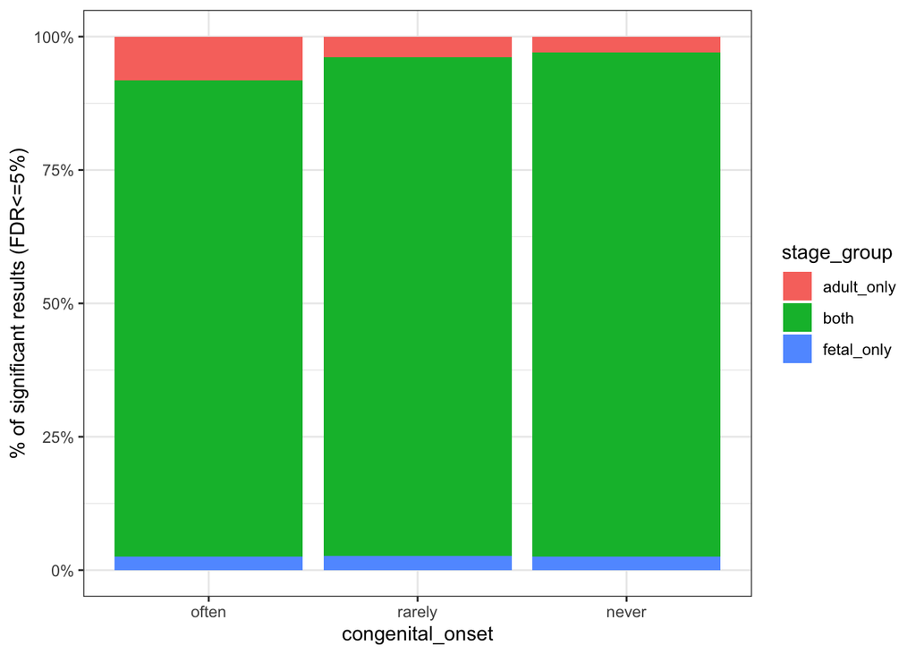

```r
ggplot(res_gpt[q<0.05,],
       aes(x=congenital_onset,
           fill=stage_group)) +
  geom_bar(position="fill") +
  scale_y_continuous(labels = scales::percent_format()) +
  labs(y="% of significant results (FDR<=5%)") +
  theme_bw()
```

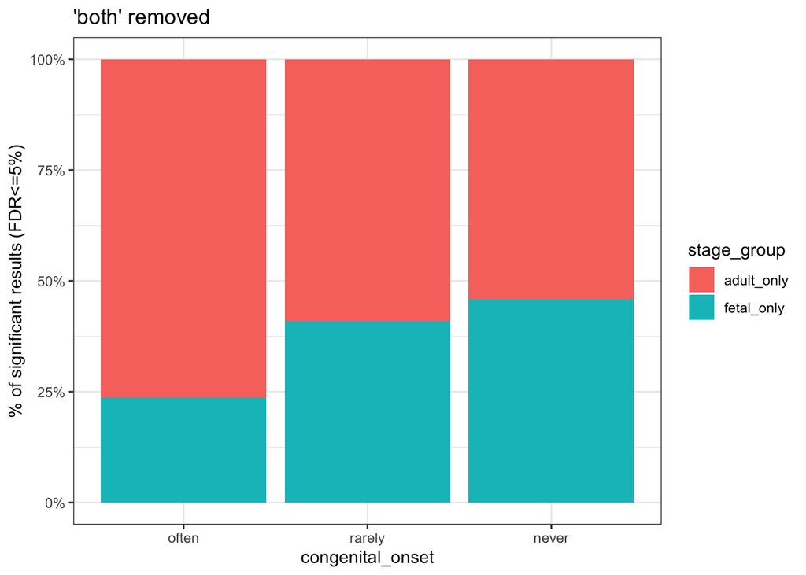

```r
ggplot(res_gpt[q<0.05 & stage_group!="both",],
       aes(x=congenital_onset,
           fill=stage_group)) +
  geom_bar(position="fill") +
  scale_y_continuous(labels = scales::percent_format()) +
  labs(y="% of significant results (FDR<=5%)",
       title="'both' removed") +
  theme_bw()
```

## Compare by substrings

Strangely, some cell types with the substrings “fetal”/“primordial”/“hESC” in them are found in the “Adult” samples as well. It’s unclear whether this is: - a mistake in the annotation - a mistake during CTD processing - a true biological phenomenon (e.g. circulating fetal cells in adult blood)

*NOTE*: I also tried using the substring “blast” but this only returned 1 cell type (“fibroblast”) which is not a fetal cell type.

```r
fetal_keywords <- c("fetal","primordial","hESC")
res_gpt[,fetal_celltype:=grepl(paste(fetal_keywords,collapse="|"),
                               celltype,
                               ignore.case = TRUE)]
res_gpt[stage=="Adult" & fetal_celltype==TRUE,]$celltype |>
  unique()
```

```
##  [1] "hESC"                         "Fetal_acinar_cell"
##  [3] "Fetal_stromal_cell"           "Fetal_enterocyte"
##  [5] "Primordial_germ_cell"         "Fetal_chondrocyte"
##  [7] "Fetal_mesenchymal_progenitor" "Fetal_fibroblast"
##  [9] "Fetal_skeletal_muscle_cell"   "Fetal_endocrine_cell"
## [11] "Fetal_epithelial_progenitor"  "Fetal_Neuron"
## [13] "Fetal_neuron"
```

If we compare only by celltype subtrings (regardless of sample stage), we find the expected relationship of a decreasing proportion of these “fetal” cell types with decreasing probability of the phenotype being congenital.

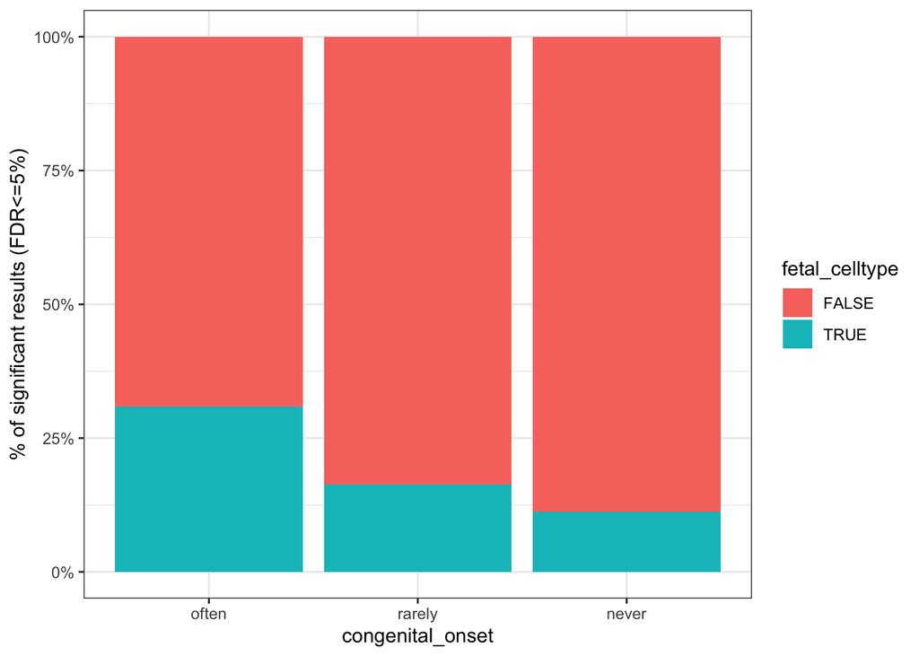

```r
ggplot(res_gpt[q<0.05,],
       aes(x=congenital_onset,
           fill=fetal_celltype)) +
  geom_bar(position="fill") +
  scale_y_continuous(labels = scales::percent_format()) +
  labs(y="% of significant results (FDR<=5%)") +
  theme_bw()
```